# Compound Figures

# Why Compound Plots?

Faceting is useful whenever we want different **rows** of the data to appear in different panels. What if we want to compare different columns, or work with several datasets? A more general alternative is to use compound plots. The idea is to construct plots separately and then combine them only at the very end.

The main advantage of compound plots is that individual panels can be tailored to specific visual comparisons, but relationships across panels can also be studied. For example, the plot below shows change in the total number and composition of undergraduate majors over the last few decades. In principle, the same information could be communicated using a stacked area plot (`geom_area`). However, comparing the percentages for 1970 and 2015 is much more straightforward using a line plot, and we can still see changes in the overall number of degrees using the area plot.

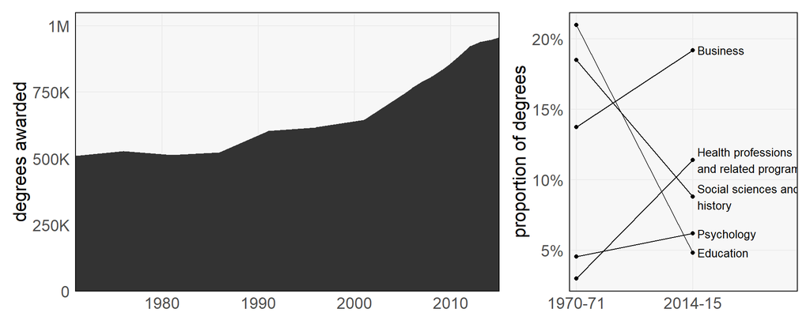

For reference, here is a non-compound display of the same information.

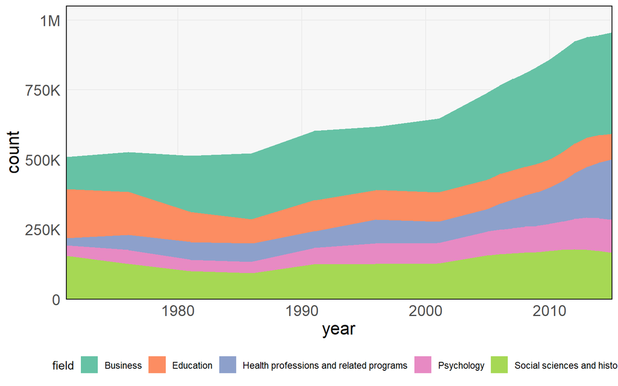

# Considerations

There are a few considerations that can substantially improve the quality of a compound plot,

- Consistent visual encodings for shared variables
- Clear, but unobtrusive annotation
- Proper alignment in figure baselines

We will discuss each point separately.

## Consistent Encodings

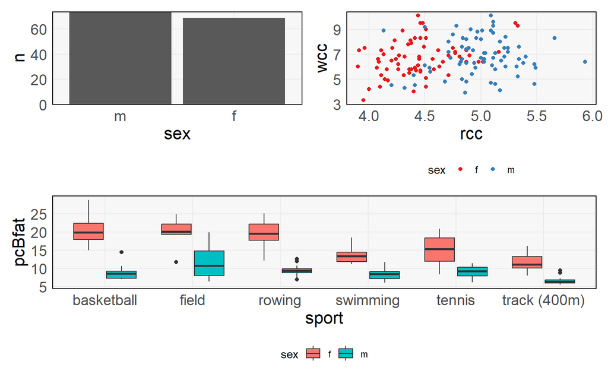

The improved, visually consistent approach is given below.

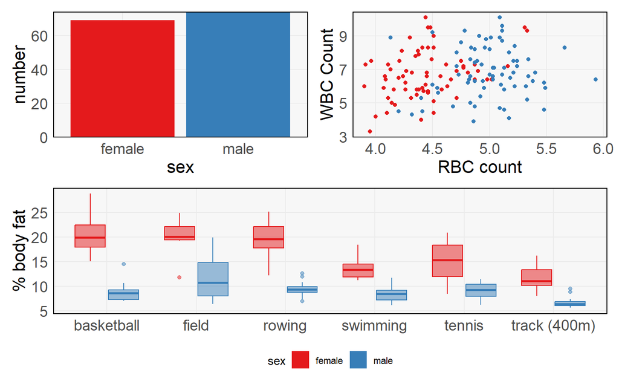

## Annotation

Effective annotation can be used to refer to different subpanels of the data without drawing too much attention to itself. Labels should be visible but subtle – not too large, similar fonts as the figures, and logically ordered (e.g. (a) on top left). A nice heuristic is to think of these annotations like page numbers. They are useful for making references, but aren’t something that is actively read.

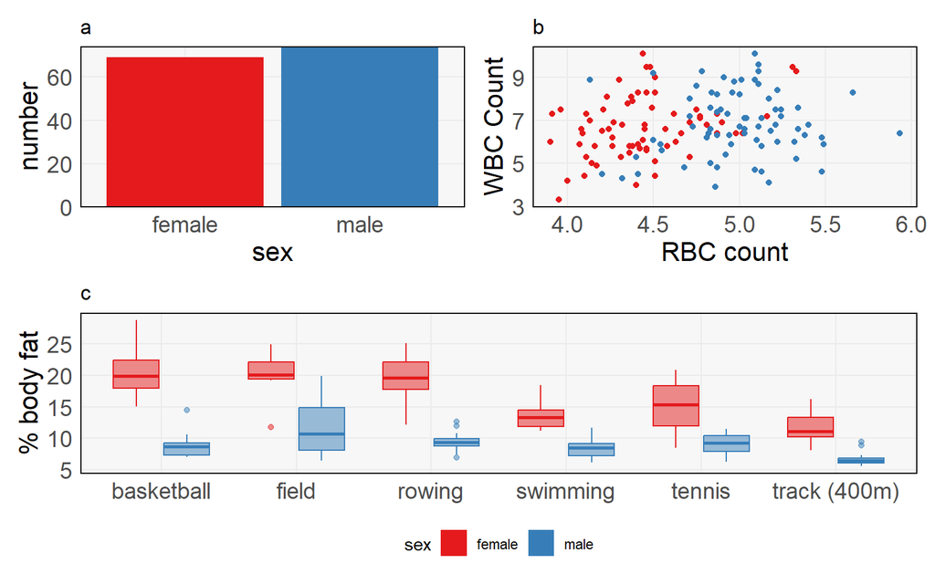

For alignment, we will want figure baselines / borders to be consistent. Misalignment can be distracting. This is primarily a problem when compound plots are made manually; for example, by pasting screenshots together into a document.

Using `patchwork` below, we won’t have this issue.

# Patchwork

The `patchwork` package does not exist to help you *make* the individual figures, rather to effectively *combine* existing figures.

This package creates a simple syntax for combining figures `p1` and `p2`,

```
* `p1 + p2` concatenates two figures horizontally
* `p1 / p2` concatenates two figures vertically
```

This idea is simple, but becomes very powerful once we realize that we can define a whole algebra on plot layouts,

```
* `p1 + p2 + p3` concatenates three figures horizontally
* `p1 / p2 / p3` concatenates three figures vertically
* `(p1 + p2) / p3` Concatenates the first two figures horizontally, and places the third below both.
* ...
```

Now, we use `patchwork` to combine the subplots using the different combinations discussed above.

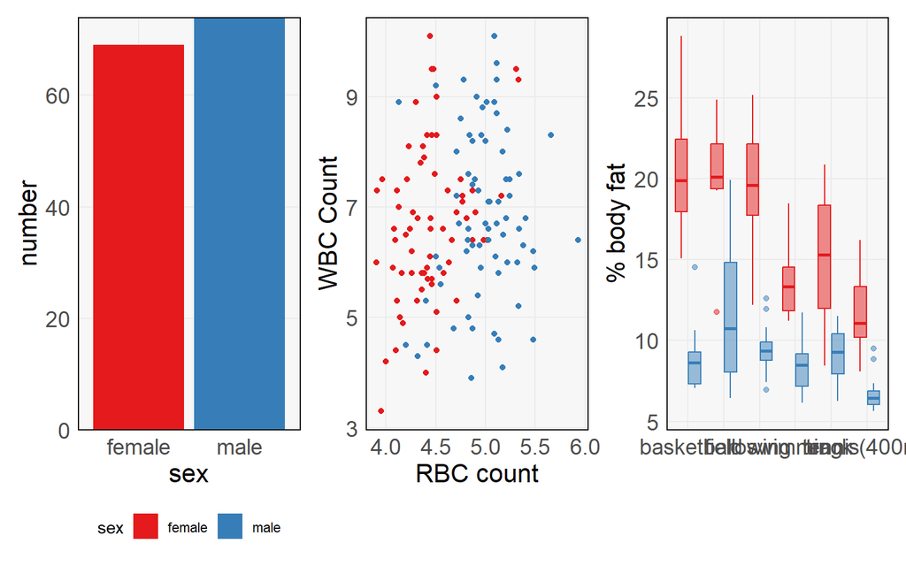

```r
    bar_plot + scatter_plot + box_plot
```

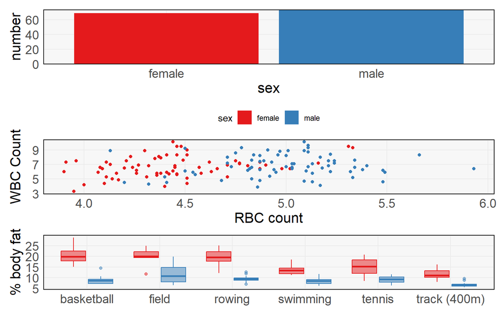

```r
    bar_plot / scatter_plot / box_plot
```

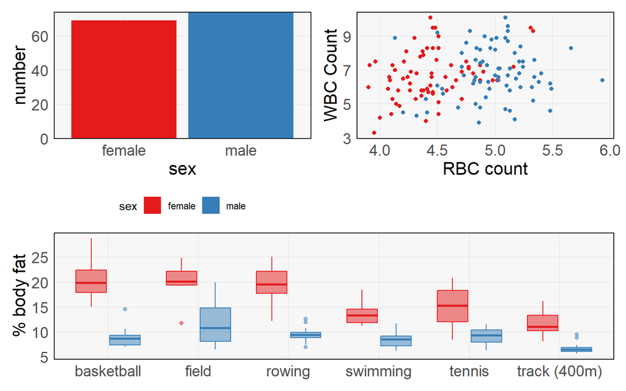

```r
    (bar_plot + scatter_plot) / box_plot
```

Here’s the version where every panel has its own legend for the same aesthetic:

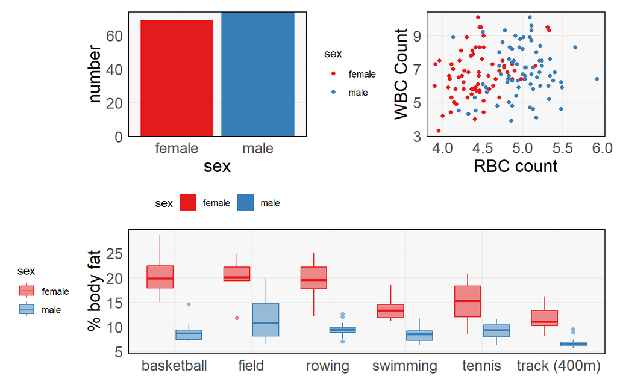

And here’s the version where the legends are collected into one:

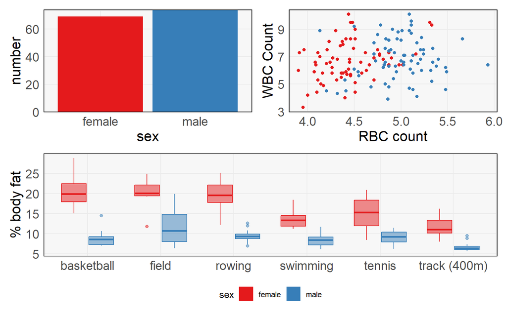

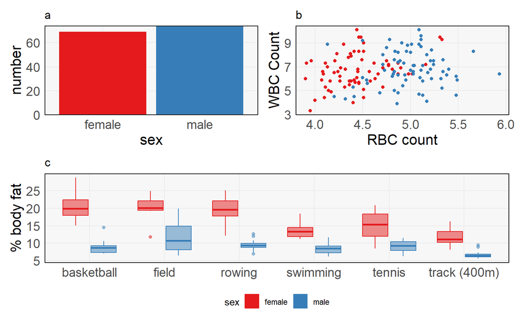

Patchwork handles alignment in the background, but sometimes we might want to have control over the relative sizes of different panels. For this, we can again use the `plot_layout` function, this time using the height and width arguments. For example, these two examples change the relative widths and heights of the layout components.

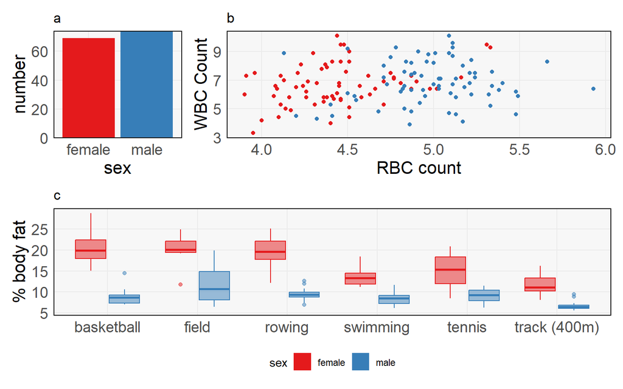

```r
    (bar_plot + scatter_plot + plot_layout(widths = c(1, 3))) / box_plot +
      plot_layout(guides = "collect")
```

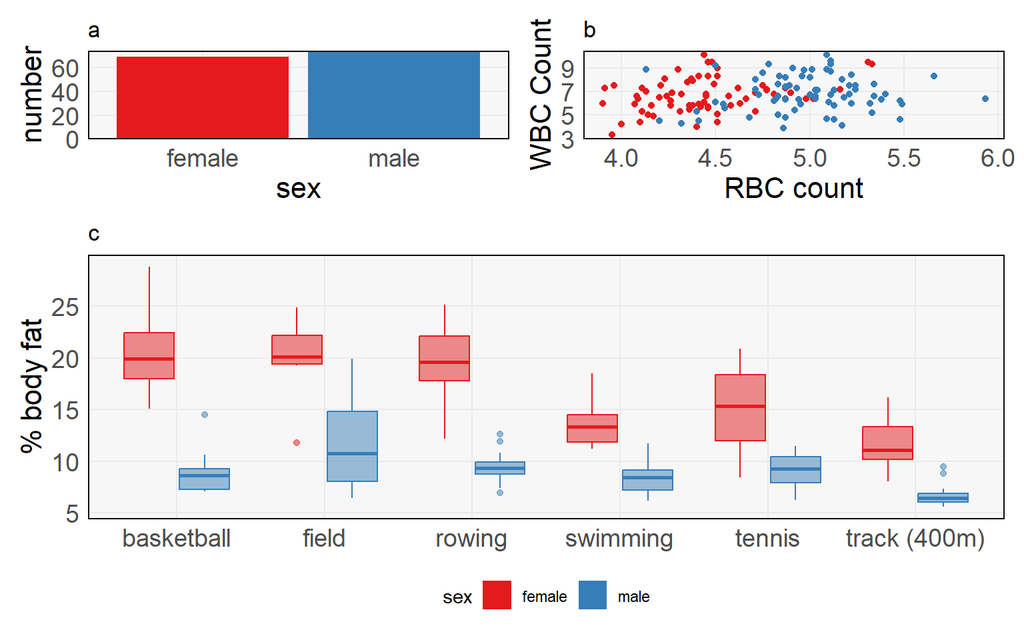

```r
    (bar_plot + scatter_plot) / box_plot +
      plot_layout(guides = "collect", heights = c(1, 3))
```